# Testosterone Gene Expression Prediction

Sneha M. Chaturvedi, Emma Jones

Last updated 2026-09-04

| **Inputs** | `data/cache/pb_base.rds`, `doc/targeted/targeted_hormones.xlsx` |
| --- | --- |
| **Outputs** | Result CSVs and figures in `results/gene-hormone/testosterone_genes/` |
| **Upstream** | `prep_data.R` |
| **Downstream** | `targeted_gene_list_limma.qmd` |

## Goals

Identify genes whose pseudobulk expression is predicted by testosterone (TT) concentration, by cell type. Analysis is **sex-separate**: XX and XY samples are modeled independently within each cell type.

**Four models tested:**

- **Base** — `~ TT`
- **Base + GW** — `~ TT + GW` (gestational week as additive covariate; justified by covariate testing)
- **Base + Batch** — `~ TT + batch1_frac` (batch1 fraction as a continuous additive covariate; both batches draw cells from the same biological samples but differ in which cells were captured)
- **Base + GW + Batch** — `~ TT + GW + batch1_frac` (both covariates)

## Set Up

- Load packages

```r
    Packages <- c(
      "tidyverse", "Seurat", "Signac", "glue", "readxl", "cowplot",
      "edgeR", "limma", "patchwork", "svglite", "Matrix", "ggpubr"
    )
    lapply(Packages, library, character.only = TRUE)

    source("pseudobulk_functions.R")
root <- find_project_root()

    set.seed(123)
```

- Load data

```r
    SSD_data <- readRDS(file.path(root, "data/cache/SSD_meta_umap.rds"))
    pb_base     <- readRDS(file.path(root, "data/cache/pb_base.rds"))
    targeted_comparison_raw <- read_xlsx(file.path(root, "doc/targeted/targeted_hormones.xlsx"))
    targeted_comparison_raw$E2 <- targeted_comparison_raw$`17B-E2 (ng/mL)`
    targeted_comparison_raw$TT <- targeted_comparison_raw$`TT (ng/mL)`
    targeted_comparison_raw$P4 <- targeted_comparison_raw$`P4 (ng/mL)`
```

- Configuration

```r
    celltype_col      <- "celltype"
    sample_col        <- "Sample"
    pb_sample_pattern <- "tissue\\d+"
```

## Outlier Removal

Samples with TT > Q3 + 1.5 × IQR are excluded before pseudobulk construction.

```r
detect_outliers <- function(data, variable) {
  outlier_limit <- quantile(data[[variable]], 0.75, na.rm = TRUE) +
    1.5 * IQR(data[[variable]], na.rm = TRUE)
  data %>% dplyr::filter(.data[[variable]] <= outlier_limit)
}

targeted_comparison_filtered_TT <- detect_outliers(targeted_comparison_raw, "TT")

cat("Samples before outlier removal:", nrow(targeted_comparison_raw), "\n")
```

```
## Samples before outlier removal: 46
```

```r
cat("Samples after outlier removal: ", nrow(targeted_comparison_filtered_TT), "\n")
```

```
## Samples after outlier removal:  43
```

```r
cat("TT range after filtering:      ",
    paste(round(range(targeted_comparison_filtered_TT$TT, na.rm = TRUE), 3),
          collapse = " – "), "ng/mL\n")
```

```
## TT range after filtering:       0 – 0.224 ng/mL
```

```r
outliers_TT <- dplyr::anti_join(targeted_comparison_raw,
                                targeted_comparison_filtered_TT, by = "Sample")

cat("TT outliers removed:",
    if (nrow(outliers_TT)) paste(outliers_TT$Sample, collapse = ", ") else "none", "\n")
```

```
## TT outliers removed: 35, 38, 50
```

## Pseudobulk

Min 30 cells per (sample × cell type) for inclusion. `add_batch_fraction()` computes the fraction of batch1 cells per biological sample and joins it onto the pseudobulk metadata.

```r
pb_TT <- merge_hormone_metadata(
  pb_base,
  targeted_comparison_filtered_TT,
  pb_sample_pattern = pb_sample_pattern,
  min_cells         = 30
)

pb_TT <- add_batch_fraction(pb_TT, SSD_data)

cat("Pseudobulk samples after merge:", nrow(pb_TT$metadata), "\n")
```

```
## Pseudobulk samples after merge: 448
```

```r
cat("batch1_frac summary:\n")
```

```
## batch1_frac summary:
```

```r
print(summary(pb_TT$metadata$batch1_frac))
```

```
##    Min. 1st Qu.  Median    Mean 3rd Qu.    Max.
##  0.0000  0.2313  0.4447  0.4217  0.5787  1.0000
```

```r
cat("NAs in batch1_frac:", sum(is.na(pb_TT$metadata$batch1_frac)), "\n")
```

```
## NAs in batch1_frac: 0
```

## Models

| Model | Formula | Rationale |
| --- | --- | --- |
| Base | `~ TT` | Direct TT–gene association |
| Base + GW | `~ TT + GW` | GW predicts transcriptome-wide expression (covariate testing) |
| Base + Batch | `~ TT + batch1_frac` | Absorbs residual expression differences between batches; continuous encoding matches the non-bimodal batch composition |
| Base + GW + Batch | `~ TT + GW + batch1_frac` | Both covariates adjusted simultaneously |

All models use `analyze_hormone()`: splits by (cell type × Sex), applies manual gene filter, drops groups below sample threshold, fits limma-voom per group.

## Base Model

`~ TT` — sex-separate, no covariates.

```r
res_TT_base <- analyze_hormone(
  pb_TT$counts, pb_TT$metadata,
  hormone               = "TT",
  min_samples           = 10,
  count_threshold       = 2,
  gene_sample_threshold = 3,
  model                 = run_voom_lm
)
```

```
##
## Group: Astrocyte-Immature.F
## Initial number of samples: 10
## Min samples required (fixed floor): 10
## Genes passing manual filter: 13633
## Samples with non-zero hormone: 2
## Group removed: insufficient non-zero hormone values 2
##
## Group: Cajal-Retzius cell.F
## Initial number of samples: 4
## Min samples required (fixed floor): 10
## Genes passing manual filter: 9227
## Samples with non-zero hormone: 0
## Group removed: insufficient non-zero hormone values 0
##
## Group: EN-IT-Immature.F
## Initial number of samples: 17
## Min samples required (fixed floor): 10
## Genes passing manual filter: 24612
## Samples with non-zero hormone: 5
## Group removed: insufficient non-zero hormone values 5
##
## Group: EN-L4-IT.F
## Initial number of samples: 6
## Min samples required (fixed floor): 10
## Genes passing manual filter: 13970
## Samples with non-zero hormone: 1
## Group removed: insufficient non-zero hormone values 1
##
## Group: EN-L5_6-NP.F
## Initial number of samples: 7
## Min samples required (fixed floor): 10
## Genes passing manual filter: 13354
## Samples with non-zero hormone: 2
## Group removed: insufficient non-zero hormone values 2
##
## Group: EN-L5-IT.F
## Initial number of samples: 1
## Min samples required (fixed floor): 10
## Genes passing manual filter: 0
```

[output cut: 278 more lines]

```
## Genes passing manual filter: 0
## Group removed: no genes passed the filter
##
## Group: RG-vRG.M
## Initial number of samples: 9
## Min samples required (fixed floor): 10
## Genes passing manual filter: 14680
## Samples with non-zero hormone: 9
## Group removed: insufficient non-zero hormone values 9
##
## Group: Unknown.M
## Initial number of samples: 1
## Min samples required (fixed floor): 10
## Genes passing manual filter: 0
## Group removed: no genes passed the filter
```

```r
summary_TT_base <- summarize_sig_genes(res_TT_base$combined_results)

plot_top_genes_from_subsets(
  res_TT_base$by_group_data,
  output_dir = file.path(root, "results/gene-hormone/testosterone_genes/run_voom_lm"),
  hormone    = "TT"
)
```

```
## Number of groups to plot: 12
```

```
##  Plotting group: Astrocyte-Immature_M
```

```
## - Significant genes (FDR < 0.1, |logFC| >= 0.25): 0
```

```
## No valid plots for group
```

```
##  Plotting group: EN-IT-Immature_M
```

```
## - Significant genes (FDR < 0.1, |logFC| >= 0.25): 0
```

```
## No valid plots for group
```

```
##  Plotting group: EN-L5_6-NP_M
```

```
## - Significant genes (FDR < 0.1, |logFC| >= 0.25): 0
```

```
## No valid plots for group
```

```
##  Plotting group: EN-L6-IT_M
```

```
## - Significant genes (FDR < 0.1, |logFC| >= 0.25): 0
```

```
## No valid plots for group
```

```
##  Plotting group: EN-L6b_M
```

```
## - Significant genes (FDR < 0.1, |logFC| >= 0.25): 0
```

```
## No valid plots for group
```

```
##  Plotting group: EN-Newborn_M
```

```
## - Significant genes (FDR < 0.1, |logFC| >= 0.25): 0
```

```
## No valid plots for group
```

```
##  Plotting group: EN-Non-IT-Immature_M
```

```
## - Significant genes (FDR < 0.1, |logFC| >= 0.25): 0
```

```
## No valid plots for group
```

```
##  Plotting group: IN-CGE-Immature_M
```

```
## - Significant genes (FDR < 0.1, |logFC| >= 0.25): 0
```

```
## No valid plots for group
```

```
##  Plotting group: IN-MGE-Immature_M
```

```
## - Significant genes (FDR < 0.1, |logFC| >= 0.25): 0
```

```
## No valid plots for group
```

```
##  Plotting group: IN-MGE-SST_M
```

```
## - Significant genes (FDR < 0.1, |logFC| >= 0.25): 0
```

```
## No valid plots for group
```

```
##  Plotting group: IPC-EN_M
```

```
## - Significant genes (FDR < 0.1, |logFC| >= 0.25): 1
```

```
##     Plotting gene: F13A1 (adj. p-value: 0.0984)
```

```
## Saved: IPC-EN_M_top_genes.png  +  svg/IPC-EN_M_top_genes.svg
##   Saved plot for IPC-EN_M
##  Plotting group: OPC_M
## - Significant genes (FDR < 0.1, |logFC| >= 0.25): 0
## No valid plots for group
```

```r
save_dual_format(
  plot_sig_gene_summary(summary_TT_base, "TT — Base (~ TT)"),
  output_dir    = file.path(root, "results/gene-hormone/testosterone_genes/run_voom_lm"),
  filename_base = "TT_base_sig_gene_summary"
)
```

```
## Saved: TT_base_sig_gene_summary.png  +  svg/TT_base_sig_gene_summary.svg
```

```r
write_csv(res_TT_base$combined_results,
          file.path(root, "results/gene-hormone/testosterone_genes/run_voom_lm/TT_base_results.csv"))
write_csv(summary_TT_base,
          file.path(root, "results/gene-hormone/testosterone_genes/run_voom_lm/TT_base_summary.csv"))
```

### Significant Genes

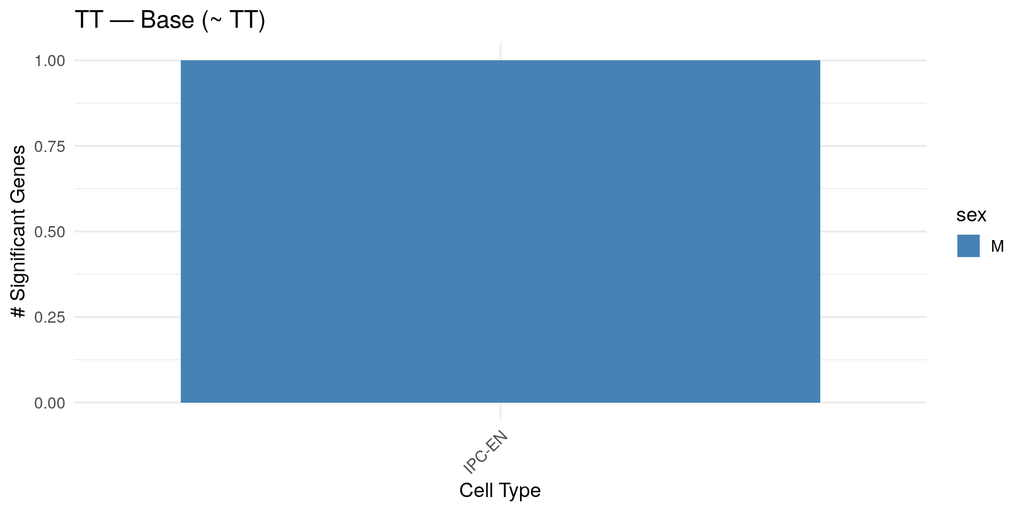

```r
plot_sig_gene_summary(summary_TT_base, "TT — Base (~ TT)")
```

### Top Results

```r
res_TT_base$combined_results %>%
  dplyr::arrange(adj.P.Val) %>%
  dplyr::select(gene, cell_type, sex, logFC, adj.P.Val) %>%
  head(10) %>%
  knitr::kable(digits = 4, caption = "Top 10 hits — Base model")
```

Top 10 hits — Base model

| gene | cell_type | sex | logFC | adj.P.Val |
| --- | --- | --- | --- | --- |
| F13A1 | IPC-EN | M | 28.6387 | 0.0984 |
| SLC28A2-AS1 | EN-Non-IT-Immature | M | 31.3292 | 0.3175 |
| GHR | EN-L6b | M | 30.6997 | 0.3566 |
| HNMT | EN-Newborn | M | -22.3103 | 0.3632 |
| ENSG00000228655 | EN-Newborn | M | 16.8899 | 0.3632 |
| FSTL1 | EN-Newborn | M | 13.0531 | 0.3632 |
| CLDN1 | EN-Newborn | M | 41.2831 | 0.3632 |
| LINC00504 | EN-Newborn | M | 10.4227 | 0.3632 |
| LDB2 | EN-Newborn | M | 20.2052 | 0.3632 |
| TACR3 | EN-Newborn | M | 28.1572 | 0.3632 |

## Base + GW

`~ TT + GW` — gestational week as additive covariate.

```r
res_TT_gw <- analyze_hormone(
  pb_TT$counts, pb_TT$metadata,
  hormone               = "TT",
  min_samples           = 10,
  count_threshold       = 2,
  gene_sample_threshold = 3,
  model                 = run_voom_lm_gw
)
```

```
##
## Group: Astrocyte-Immature.F
## Initial number of samples: 10
## Min samples required (fixed floor): 10
## Genes passing manual filter: 13633
## Samples with non-zero hormone: 2
## Group removed: insufficient non-zero hormone values 2
##
## Group: Cajal-Retzius cell.F
## Initial number of samples: 4
## Min samples required (fixed floor): 10
## Genes passing manual filter: 9227
## Samples with non-zero hormone: 0
## Group removed: insufficient non-zero hormone values 0
##
## Group: EN-IT-Immature.F
## Initial number of samples: 17
## Min samples required (fixed floor): 10
## Genes passing manual filter: 24612
## Samples with non-zero hormone: 5
## Group removed: insufficient non-zero hormone values 5
##
## Group: EN-L4-IT.F
## Initial number of samples: 6
## Min samples required (fixed floor): 10
## Genes passing manual filter: 13970
## Samples with non-zero hormone: 1
## Group removed: insufficient non-zero hormone values 1
##
## Group: EN-L5_6-NP.F
## Initial number of samples: 7
## Min samples required (fixed floor): 10
## Genes passing manual filter: 13354
## Samples with non-zero hormone: 2
## Group removed: insufficient non-zero hormone values 2
##
## Group: EN-L5-IT.F
## Initial number of samples: 1
## Min samples required (fixed floor): 10
## Genes passing manual filter: 0
```

[output cut: 278 more lines]

```
## Genes passing manual filter: 0
## Group removed: no genes passed the filter
##
## Group: RG-vRG.M
## Initial number of samples: 9
## Min samples required (fixed floor): 10
## Genes passing manual filter: 14680
## Samples with non-zero hormone: 9
## Group removed: insufficient non-zero hormone values 9
##
## Group: Unknown.M
## Initial number of samples: 1
## Min samples required (fixed floor): 10
## Genes passing manual filter: 0
## Group removed: no genes passed the filter
```

```r
summary_TT_gw <- summarize_sig_genes(res_TT_gw$combined_results)

plot_top_genes_from_subsets(
  res_TT_gw$by_group_data,
  output_dir = file.path(root, "results/gene-hormone/testosterone_genes/run_voom_lm_gw"),
  hormone    = "TT"
)
```

```
## Number of groups to plot: 12
```

```
##  Plotting group: Astrocyte-Immature_M
```

```
## - Significant genes (FDR < 0.1, |logFC| >= 0.25): 0
```

```
## No valid plots for group
```

```
##  Plotting group: EN-IT-Immature_M
```

```
## - Significant genes (FDR < 0.1, |logFC| >= 0.25): 0
```

```
## No valid plots for group
```

```
##  Plotting group: EN-L5_6-NP_M
```

```
## - Significant genes (FDR < 0.1, |logFC| >= 0.25): 0
```

```
## No valid plots for group
```

```
##  Plotting group: EN-L6-IT_M
```

```
## - Significant genes (FDR < 0.1, |logFC| >= 0.25): 0
```

```
## No valid plots for group
```

```
##  Plotting group: EN-L6b_M
```

```
## - Significant genes (FDR < 0.1, |logFC| >= 0.25): 0
```

```
## No valid plots for group
```

```
##  Plotting group: EN-Newborn_M
```

```
## - Significant genes (FDR < 0.1, |logFC| >= 0.25): 0
```

```
## No valid plots for group
```

```
##  Plotting group: EN-Non-IT-Immature_M
```

```
## - Significant genes (FDR < 0.1, |logFC| >= 0.25): 0
```

```
## No valid plots for group
```

```
##  Plotting group: IN-CGE-Immature_M
```

```
## - Significant genes (FDR < 0.1, |logFC| >= 0.25): 0
```

```
## No valid plots for group
```

```
##  Plotting group: IN-MGE-Immature_M
```

```
## - Significant genes (FDR < 0.1, |logFC| >= 0.25): 0
```

```
## No valid plots for group
```

```
##  Plotting group: IN-MGE-SST_M
```

```
## - Significant genes (FDR < 0.1, |logFC| >= 0.25): 0
```

```
## No valid plots for group
```

```
##  Plotting group: IPC-EN_M
```

```
## - Significant genes (FDR < 0.1, |logFC| >= 0.25): 0
```

```
## No valid plots for group
```

```
##  Plotting group: OPC_M
```

```
## - Significant genes (FDR < 0.1, |logFC| >= 0.25): 0
```

```
## No valid plots for group
```

```r
save_dual_format(
  plot_sig_gene_summary(summary_TT_gw, "TT — Base + GW (~ TT + GW)"),
  output_dir    = file.path(root, "results/gene-hormone/testosterone_genes/run_voom_lm_gw"),
  filename_base = "TT_gw_sig_gene_summary"
)
```

```
## Saved: TT_gw_sig_gene_summary.png  +  svg/TT_gw_sig_gene_summary.svg
```

```r
write_csv(res_TT_gw$combined_results,
          file.path(root, "results/gene-hormone/testosterone_genes/run_voom_lm_gw/TT_gw_results.csv"))
write_csv(summary_TT_gw,
          file.path(root, "results/gene-hormone/testosterone_genes/run_voom_lm_gw/TT_gw_summary.csv"))
```

### Significant Genes

[figure not shown]

```r
plot_sig_gene_summary(summary_TT_gw, "TT — Base + GW (~ TT + GW)")
```

### Top Results

```r
res_TT_gw$combined_results %>%
  dplyr::arrange(adj.P.Val) %>%
  dplyr::select(gene, cell_type, sex, logFC, adj.P.Val) %>%
  head(10) %>%
  knitr::kable(digits = 4, caption = "Top 10 hits — Base + GW model")
```

Top 10 hits — Base + GW model

| gene | cell_type | sex | logFC | adj.P.Val |
| --- | --- | --- | --- | --- |
| P3H2-AS1 | EN-L6-IT | M | 17.6629 | 0.1682 |
| STXBP6 | EN-L6-IT | M | 18.1546 | 0.1682 |
| RASL10A | EN-L6-IT | M | -26.2524 | 0.1682 |
| LHFPL2 | EN-L5_6-NP | M | -21.5933 | 0.1820 |
| NTS | EN-L5_6-NP | M | -52.5436 | 0.1820 |
| STXBP5L | EN-L5_6-NP | M | -20.1695 | 0.1983 |
| CRAT37 | EN-L5_6-NP | M | -30.6609 | 0.1983 |
| CXXC4-AS1 | EN-L5_6-NP | M | 17.8358 | 0.2025 |
| ADGRG2 | EN-L5_6-NP | M | -28.7245 | 0.2252 |
| FBXL7 | EN-IT-Immature | M | -16.2642 | 0.3181 |

## Base + Batch

`~ TT + batch1_frac` — batch1 fraction (continuous) as additive covariate.

```r
res_TT_batch <- analyze_hormone(
  pb_TT$counts, pb_TT$metadata,
  hormone               = "TT",
  min_samples           = 10,
  count_threshold       = 2,
  gene_sample_threshold = 3,
  model                 = run_voom_lm_batch
)
```

```
##
## Group: Astrocyte-Immature.F
## Initial number of samples: 10
## Min samples required (fixed floor): 10
## Genes passing manual filter: 13633
## Samples with non-zero hormone: 2
## Group removed: insufficient non-zero hormone values 2
##
## Group: Cajal-Retzius cell.F
## Initial number of samples: 4
## Min samples required (fixed floor): 10
## Genes passing manual filter: 9227
## Samples with non-zero hormone: 0
## Group removed: insufficient non-zero hormone values 0
##
## Group: EN-IT-Immature.F
## Initial number of samples: 17
## Min samples required (fixed floor): 10
## Genes passing manual filter: 24612
## Samples with non-zero hormone: 5
## Group removed: insufficient non-zero hormone values 5
##
## Group: EN-L4-IT.F
## Initial number of samples: 6
## Min samples required (fixed floor): 10
## Genes passing manual filter: 13970
## Samples with non-zero hormone: 1
## Group removed: insufficient non-zero hormone values 1
##
## Group: EN-L5_6-NP.F
## Initial number of samples: 7
## Min samples required (fixed floor): 10
## Genes passing manual filter: 13354
## Samples with non-zero hormone: 2
## Group removed: insufficient non-zero hormone values 2
##
## Group: EN-L5-IT.F
## Initial number of samples: 1
## Min samples required (fixed floor): 10
## Genes passing manual filter: 0
```

[output cut: 278 more lines]

```
## Genes passing manual filter: 0
## Group removed: no genes passed the filter
##
## Group: RG-vRG.M
## Initial number of samples: 9
## Min samples required (fixed floor): 10
## Genes passing manual filter: 14680
## Samples with non-zero hormone: 9
## Group removed: insufficient non-zero hormone values 9
##
## Group: Unknown.M
## Initial number of samples: 1
## Min samples required (fixed floor): 10
## Genes passing manual filter: 0
## Group removed: no genes passed the filter
```

```r
summary_TT_batch <- summarize_sig_genes(res_TT_batch$combined_results)

plot_top_genes_from_subsets(
  res_TT_batch$by_group_data,
  output_dir = file.path(root, "results/gene-hormone/testosterone_genes/run_voom_lm_batch"),
  hormone    = "TT"
)
```

```
## Number of groups to plot: 12
```

```
##  Plotting group: Astrocyte-Immature_M
```

```
## - Significant genes (FDR < 0.1, |logFC| >= 0.25): 0
```

```
## No valid plots for group
```

```
##  Plotting group: EN-IT-Immature_M
```

```
## - Significant genes (FDR < 0.1, |logFC| >= 0.25): 0
```

```
## No valid plots for group
```

```
##  Plotting group: EN-L5_6-NP_M
```

```
## - Significant genes (FDR < 0.1, |logFC| >= 0.25): 0
```

```
## No valid plots for group
```

```
##  Plotting group: EN-L6-IT_M
```

```
## - Significant genes (FDR < 0.1, |logFC| >= 0.25): 0
```

```
## No valid plots for group
```

```
##  Plotting group: EN-L6b_M
```

```
## - Significant genes (FDR < 0.1, |logFC| >= 0.25): 0
```

```
## No valid plots for group
```

```
##  Plotting group: EN-Newborn_M
```

```
## - Significant genes (FDR < 0.1, |logFC| >= 0.25): 0
```

```
## No valid plots for group
```

```
##  Plotting group: EN-Non-IT-Immature_M
```

```
## - Significant genes (FDR < 0.1, |logFC| >= 0.25): 0
```

```
## No valid plots for group
```

```
##  Plotting group: IN-CGE-Immature_M
```

```
## - Significant genes (FDR < 0.1, |logFC| >= 0.25): 0
```

```
## No valid plots for group
```

```
##  Plotting group: IN-MGE-Immature_M
```

```
## - Significant genes (FDR < 0.1, |logFC| >= 0.25): 0
```

```
## No valid plots for group
```

```
##  Plotting group: IN-MGE-SST_M
```

```
## - Significant genes (FDR < 0.1, |logFC| >= 0.25): 0
```

```
## No valid plots for group
```

```
##  Plotting group: IPC-EN_M
```

```
## - Significant genes (FDR < 0.1, |logFC| >= 0.25): 0
```

```
## No valid plots for group
```

```
##  Plotting group: OPC_M
```

```
## - Significant genes (FDR < 0.1, |logFC| >= 0.25): 0
```

```
## No valid plots for group
```

```r
save_dual_format(
  plot_sig_gene_summary(summary_TT_batch, "TT — Base + Batch (~ TT + batch1_frac)"),
  output_dir    = file.path(root, "results/gene-hormone/testosterone_genes/run_voom_lm_batch"),
  filename_base = "TT_batch_sig_gene_summary"
)
```

```
## Saved: TT_batch_sig_gene_summary.png  +  svg/TT_batch_sig_gene_summary.svg
```

```r
write_csv(res_TT_batch$combined_results,
          file.path(root, "results/gene-hormone/testosterone_genes/run_voom_lm_batch/TT_batch_results.csv"))
write_csv(summary_TT_batch,
          file.path(root, "results/gene-hormone/testosterone_genes/run_voom_lm_batch/TT_batch_summary.csv"))
```

### Significant Genes

[figure not shown]

```r
plot_sig_gene_summary(summary_TT_batch, "TT — Base + Batch (~ TT + batch1_frac)")
```

### Top Results

```r
res_TT_batch$combined_results %>%
  dplyr::arrange(adj.P.Val) %>%
  dplyr::select(gene, cell_type, sex, logFC, adj.P.Val) %>%
  head(10) %>%
  knitr::kable(digits = 4, caption = "Top 10 hits — Base + Batch model")
```

Top 10 hits — Base + Batch model

| gene | cell_type | sex | logFC | adj.P.Val |
| --- | --- | --- | --- | --- |
| F13A1 | IPC-EN | M | 28.8483 | 0.1545 |
| FSTL1 | EN-Newborn | M | 13.1912 | 0.3906 |
| GHR | EN-L6b | M | 30.3372 | 0.4196 |
| F10 | EN-L6b | M | 16.6449 | 0.4196 |
| SLC28A2-AS1 | EN-Non-IT-Immature | M | 30.6801 | 0.5138 |
| ENSG00000228999 | EN-Non-IT-Immature | M | 19.7826 | 0.5290 |
| EMB | EN-Non-IT-Immature | M | 22.0660 | 0.5290 |
| TCTE1 | EN-Non-IT-Immature | M | 16.0116 | 0.5290 |
| TES | EN-Non-IT-Immature | M | -14.7441 | 0.5290 |
| LINC03056 | EN-Non-IT-Immature | M | 22.0314 | 0.5290 |

## Base + GW + Batch

`~ TT + GW + batch1_frac` — gestational week and batch1 fraction as simultaneous additive covariates.

```r
res_TT_gw_batch <- analyze_hormone(
  pb_TT$counts, pb_TT$metadata,
  hormone               = "TT",
  min_samples           = 10,
  count_threshold       = 2,
  gene_sample_threshold = 3,
  model                 = run_voom_lm_gw_batch
)
```

```
##
## Group: Astrocyte-Immature.F
## Initial number of samples: 10
## Min samples required (fixed floor): 10
## Genes passing manual filter: 13633
## Samples with non-zero hormone: 2
## Group removed: insufficient non-zero hormone values 2
##
## Group: Cajal-Retzius cell.F
## Initial number of samples: 4
## Min samples required (fixed floor): 10
## Genes passing manual filter: 9227
## Samples with non-zero hormone: 0
## Group removed: insufficient non-zero hormone values 0
##
## Group: EN-IT-Immature.F
## Initial number of samples: 17
## Min samples required (fixed floor): 10
## Genes passing manual filter: 24612
## Samples with non-zero hormone: 5
## Group removed: insufficient non-zero hormone values 5
##
## Group: EN-L4-IT.F
## Initial number of samples: 6
## Min samples required (fixed floor): 10
## Genes passing manual filter: 13970
## Samples with non-zero hormone: 1
## Group removed: insufficient non-zero hormone values 1
##
## Group: EN-L5_6-NP.F
## Initial number of samples: 7
## Min samples required (fixed floor): 10
## Genes passing manual filter: 13354
## Samples with non-zero hormone: 2
## Group removed: insufficient non-zero hormone values 2
##
## Group: EN-L5-IT.F
## Initial number of samples: 1
## Min samples required (fixed floor): 10
## Genes passing manual filter: 0
```

[output cut: 278 more lines]

```
## Genes passing manual filter: 0
## Group removed: no genes passed the filter
##
## Group: RG-vRG.M
## Initial number of samples: 9
## Min samples required (fixed floor): 10
## Genes passing manual filter: 14680
## Samples with non-zero hormone: 9
## Group removed: insufficient non-zero hormone values 9
##
## Group: Unknown.M
## Initial number of samples: 1
## Min samples required (fixed floor): 10
## Genes passing manual filter: 0
## Group removed: no genes passed the filter
```

```r
summary_TT_gw_batch <- summarize_sig_genes(res_TT_gw_batch$combined_results)

plot_top_genes_from_subsets(
  res_TT_gw_batch$by_group_data,
  output_dir = file.path(root, "results/gene-hormone/testosterone_genes/run_voom_lm_gw_batch"),
  hormone    = "TT"
)
```

```
## Number of groups to plot: 12
```

```
##  Plotting group: Astrocyte-Immature_M
```

```
## - Significant genes (FDR < 0.1, |logFC| >= 0.25): 0
```

```
## No valid plots for group
```

```
##  Plotting group: EN-IT-Immature_M
```

```
## - Significant genes (FDR < 0.1, |logFC| >= 0.25): 0
```

```
## No valid plots for group
```

```
##  Plotting group: EN-L5_6-NP_M
```

```
## - Significant genes (FDR < 0.1, |logFC| >= 0.25): 0
```

```
## No valid plots for group
```

```
##  Plotting group: EN-L6-IT_M
```

```
## - Significant genes (FDR < 0.1, |logFC| >= 0.25): 0
```

```
## No valid plots for group
```

```
##  Plotting group: EN-L6b_M
```

```
## - Significant genes (FDR < 0.1, |logFC| >= 0.25): 0
```

```
## No valid plots for group
```

```
##  Plotting group: EN-Newborn_M
```

```
## - Significant genes (FDR < 0.1, |logFC| >= 0.25): 0
```

```
## No valid plots for group
```

```
##  Plotting group: EN-Non-IT-Immature_M
```

```
## - Significant genes (FDR < 0.1, |logFC| >= 0.25): 0
```

```
## No valid plots for group
```

```
##  Plotting group: IN-CGE-Immature_M
```

```
## - Significant genes (FDR < 0.1, |logFC| >= 0.25): 0
```

```
## No valid plots for group
```

```
##  Plotting group: IN-MGE-Immature_M
```

```
## - Significant genes (FDR < 0.1, |logFC| >= 0.25): 0
```

```
## No valid plots for group
```

```
##  Plotting group: IN-MGE-SST_M
```

```
## - Significant genes (FDR < 0.1, |logFC| >= 0.25): 0
```

```
## No valid plots for group
```

```
##  Plotting group: IPC-EN_M
```

```
## - Significant genes (FDR < 0.1, |logFC| >= 0.25): 0
```

```
## No valid plots for group
```

```
##  Plotting group: OPC_M
```

```
## - Significant genes (FDR < 0.1, |logFC| >= 0.25): 0
```

```
## No valid plots for group
```

```r
save_dual_format(
  plot_sig_gene_summary(summary_TT_gw_batch,
                        "TT — Base + GW + Batch (~ TT + GW + batch1_frac)"),
  output_dir    = file.path(root, "results/gene-hormone/testosterone_genes/run_voom_lm_gw_batch"),
  filename_base = "TT_gw_batch_sig_gene_summary"
)
```

```
## Saved: TT_gw_batch_sig_gene_summary.png  +  svg/TT_gw_batch_sig_gene_summary.svg
```

```r
write_csv(res_TT_gw_batch$combined_results,
          file.path(root, "results/gene-hormone/testosterone_genes/run_voom_lm_gw_batch/TT_gw_batch_results.csv"))
write_csv(summary_TT_gw_batch,
          file.path(root, "results/gene-hormone/testosterone_genes/run_voom_lm_gw_batch/TT_gw_batch_summary.csv"))
```

### Significant Genes

[figure not shown]

```r
plot_sig_gene_summary(summary_TT_gw_batch,
                      "TT — Base + GW + Batch (~ TT + GW + batch1_frac)")
```

### Top Results

```r
res_TT_gw_batch$combined_results %>%
  dplyr::arrange(adj.P.Val) %>%
  dplyr::select(gene, cell_type, sex, logFC, adj.P.Val) %>%
  head(10) %>%
  knitr::kable(digits = 4, caption = "Top 10 hits — Base + GW + Batch model")
```

Top 10 hits — Base + GW + Batch model

| gene | cell_type | sex | logFC | adj.P.Val |
| --- | --- | --- | --- | --- |
| STXBP6 | EN-L6-IT | M | 18.1035 | 0.1549 |
| RASL10A | EN-L6-IT | M | -21.1192 | 0.1549 |
| P3H2-AS1 | EN-L6-IT | M | 17.6130 | 0.2035 |
| STXBP5L | EN-L5_6-NP | M | -21.1423 | 0.2307 |
| LHFPL2 | EN-L5_6-NP | M | -23.4138 | 0.2307 |
| ENSG00000271860 | EN-L5_6-NP | M | 29.7715 | 0.2307 |
| NTS | EN-L5_6-NP | M | -54.4896 | 0.2307 |
| S100A10 | EN-L6-IT | M | -18.7244 | 0.4124 |
| CXXC4-AS1 | EN-L5_6-NP | M | 17.5511 | 0.4358 |
| ETV1 | EN-L5_6-NP | M | -21.9648 | 0.4358 |

## Summary

```r
cross_model_TT <- dplyr::bind_rows(
  summarize_sig_genes(res_TT_base$combined_results)     %>%
    dplyr::mutate(model = "~ TT"),
  summarize_sig_genes(res_TT_gw$combined_results)       %>%
    dplyr::mutate(model = "~ TT + GW"),
  summarize_sig_genes(res_TT_batch$combined_results)    %>%
    dplyr::mutate(model = "~ TT + batch1_frac"),
  summarize_sig_genes(res_TT_gw_batch$combined_results) %>%
    dplyr::mutate(model = "~ TT + GW + batch1_frac")
)

knitr::kable(
  cross_model_TT %>%
    dplyr::select(model, cell_type, sex, num_sig_genes) %>%
    dplyr::arrange(model, desc(num_sig_genes)),
  caption = "Significant genes (FDR < 0.10, |logFC| ≥ 0.25) per model"
)
```

Significant genes (FDR < 0.10, |logFC| ≥ 0.25) per model

| model | cell_type | sex | num_sig_genes |
| --- | --- | --- | --- |
| ~ TT | IPC-EN | M | 1 |

```r
cross_model_TT %>%
  dplyr::group_by(model) %>%
  dplyr::summarise(total_sig_genes = sum(num_sig_genes), .groups = "drop") %>%
  knitr::kable(caption = "Total significant genes per model")
```

Total significant genes per model

| model | total_sig_genes |
| --- | --- |
| ~ TT | 1 |

## Analysis UMAP

XY cells from included groups are colored by cell type; all XX cells and cells from excluded cell types are shown in grey.

```r
plot_analysis_umap(
  seurat_obj    = SSD_data,
  by_group_data = res_TT_base$by_group_data,
  title         = "Testosterone Analysis — Included Cells (XY)",
  sex_separate  = TRUE,
  output_dir    = file.path(root, "results/gene-hormone/testosterone_genes"),
  filename_base = "TT_analysis_umap"
)
```

```
## plot_analysis_umap [Testosterone Analysis — Included Cells (XY)]: 59489 included cells (47.0%), 67000 excluded
```

```
## Saved: TT_analysis_umap.png  +  svg/TT_analysis_umap.svg
```

## AI Assistance Disclosure

Code in this script was developed with assistance from Claude (Anthropic). All AI-generated code was reviewed, validated, and adapted by the author.